# AI 221 Machine Exercise 3

## Wine Quality Dataset

#### by Quiel Andrew I. Quiwa

In this machine exercise, we will us the Red Portuguese "Vinho Verde" dataset from the UCI Machine Learning Repository to predict the quality of wine. The dataset contains 1,599 samples and 11 physicochemical attributes. We will be using SVM, MLP, Random Forest, and Gradient Boosting to compare results with a previous study on the dataset that utilized regression models.

```python
import numpy as np
import pandas as pd
import matplotlib.pyplot as plt
import seaborn as sns

from sklearn.model_selection import train_test_split
from sklearn.svm import SVC
from sklearn.pipeline import make_pipeline
from sklearn.preprocessing import StandardScaler
from sklearn.neural_network import MLPClassifier
from sklearn.ensemble import RandomForestClassifier, GradientBoostingClassifier
from sklearn.metrics import classification_report, confusion_matrix, accuracy_score, f1_score
from sklearn.model_selection import GridSearchCV

## For MLP
from sklearn.model_selection import RandomizedSearchCV
import warnings
from sklearn.exceptions import ConvergenceWarning
warnings.filterwarnings('ignore', category=ConvergenceWarning)
```

### Load Dataset

First, we will load the red wine CSV file. Each row is a wine sample with 11 physicochemical input features and a `quality` score (0–10) graded by expert tasters. We will inspect the data with `.info()` to check for missing values.

```python
wine_df = pd.read_csv('winequality-red.csv', sep=';')
wine_df.info()
```

```
<class 'pandas.core.frame.DataFrame'>
RangeIndex: 1599 entries, 0 to 1598
Data columns (total 12 columns):
 #   Column                Non-Null Count  Dtype
---  ------                --------------  -----
 0   fixed acidity         1599 non-null   float64
 1   volatile acidity      1599 non-null   float64
 2   citric acid           1599 non-null   float64
 3   residual sugar        1599 non-null   float64
 4   chlorides             1599 non-null   float64
 5   free sulfur dioxide   1599 non-null   float64
 6   total sulfur dioxide  1599 non-null   float64
 7   density               1599 non-null   float64
 8   pH                    1599 non-null   float64
 9   sulphates             1599 non-null   float64
 10  alcohol               1599 non-null   float64
 11  quality               1599 non-null   int64
dtypes: float64(11), int64(1)
memory usage: 150.0 KB
```

### Exploratory Data Analysis

We will use a pairplot to visualize pairwise relationships between all features, colored by the `quality` score. This helps identify which physicochemical attributes are most discriminative for predicting wine quality before training any model.

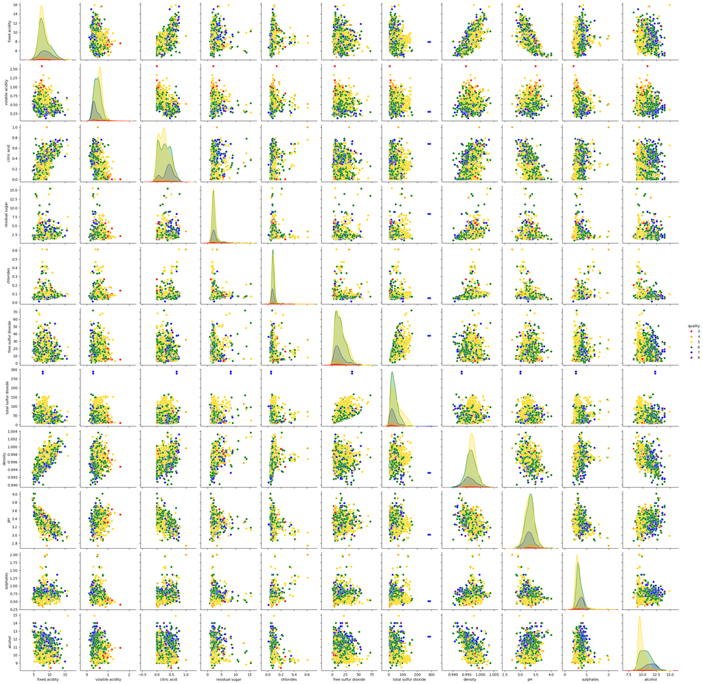

```python
palette = {3: 'red', 4: 'orange', 5: 'gold', 6: 'green', 7: 'blue', 8: 'purple'}
sns.pairplot(wine_df, hue='quality', palette=palette)
plt.show()
```

#### EDA Observation

Immediately, we can see that majority of the dataset are gold (quality=5) and green (quality=6). There is class imbalance in the dataset.

Additionally, it seems like there is no single feature that cleanly separates all classes. Even alcohol which shows a relatively clearer color gradient with the lower quality wines clustering toward the left, it's still difficult to see visually.

### Train/Test Split

First, we'll separate the label column (quality) from the rest of the columns/features in the dataset. Afterwards, we'll split the train/test into 70/30, stratified by the labels since we know that the dataset is imbalanced.

```python
features = wine_df.drop('quality', axis=1)
labels = wine_df['quality']

X_train, X_test, y_train, y_test = train_test_split(features, labels, test_size=0.3, random_state=42, stratify=labels)

print("Shape of X_train (training data):", X_train.shape)
print("Shape of y_train (training labels):", y_train.shape)
print("Shape of X_test (test data):", X_test.shape)
print("Shape of y_test (test labels):", y_test.shape)
```

```
Shape of X_train (training data): (1119, 11)
Shape of y_train (training labels): (1119,)
Shape of X_test (test data): (480, 11)
Shape of y_test (test labels): (480,)
```

# Classification

### 1. SVM

```python
pipeline = make_pipeline(StandardScaler(), SVC(kernel='rbf', random_state=42))
```

#### Pipeline Definition

We define a `Pipeline` that chains `StandardScaler` (feature normalization) with `SVC`. Scaling is critical for SVM because the algorithm is sensitive to the magnitude of input features. Without it, features with large ranges would dominate the kernel distance calculations.

```python
param_grid = {
    'svc__C': [0.5, 1, 2, 5, 10],
    'svc__gamma': [0.05, 0.1, 0.2, 'scale'],
    'svc__kernel': ['rbf']
}

grid_search = GridSearchCV(pipeline, param_grid, cv=5, scoring='accuracy', n_jobs=-1, verbose=1)
grid_search.fit(X_train, y_train)

print("Best parameters:", grid_search.best_params_)
print("Best CV accuracy: {:.4f}".format(grid_search.best_score_))
```

```
Fitting 5 folds for each of 20 candidates, totalling 100 fits
Best parameters: {'svc__C': 1, 'svc__gamma': 0.2, 'svc__kernel': 'rbf'}
Best CV accuracy: 0.6139
```

#### SVM Hyperparameter Tuning

A Support Vector Machine (SVM) finds the optimal hyperplane that best separates classes in a high-dimensional feature space. It uses a kernel function (e.g. RBF) to handle non-linear boundaries, making it well-suited for complex datasets like wine quality where classes are not linearly separable.

Rather than accepting default parameters, we use `GridSearchCV` with 5-fold cross-validation to search for the best combination of `C` (regularization strength), `gamma` (kernel coefficient), and `kernel` type. This improves on the heuristic-based tuning used in the original paper.

```python
best_svm = grid_search.best_estimator_
y_pred_svm = best_svm.predict(X_test)

print("SVM Classification Report")
print(classification_report(y_test, y_pred_svm, zero_division=0))
print("Accuracy:  {:.4f}".format(accuracy_score(y_test, y_pred_svm)))
```

```
SVM Classification Report
              precision    recall  f1-score   support

           3       0.00      0.00      0.00         3
           4       0.00      0.00      0.00        16
           5       0.66      0.78      0.71       204
           6       0.56      0.64      0.60       192
           7       0.74      0.28      0.41        60
           8       0.00      0.00      0.00         5

    accuracy                           0.62       480
   macro avg       0.33      0.28      0.29       480
weighted avg       0.60      0.62      0.59       480

Accuracy:  0.6208
```

#### SVM Evaluation on Test Data

Using the best hyperparameters found by `GridSearchCV`, we predict wine quality on the held-out test set (30% of the data).

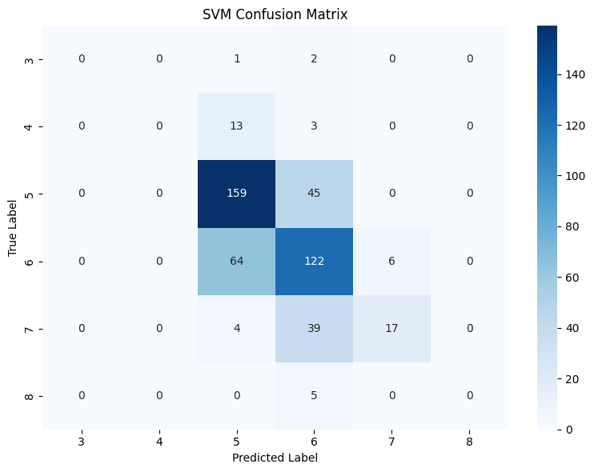

```python
cm_svm = confusion_matrix(y_test, y_pred_svm)
plt.figure(figsize=(8, 6))
sns.heatmap(cm_svm, annot=True, fmt='d', cmap='Blues',
            xticklabels=sorted(labels.unique()),
            yticklabels=sorted(labels.unique()))
plt.title('SVM Confusion Matrix')
plt.xlabel('Predicted Label')
plt.ylabel('True Label')
plt.tight_layout()
plt.show()
```

#### SVM Confusion Matrix

The confusion matrix shows the full distribution of correct and incorrect predictions across all quality classes. Rows represent the true label, columns represent the predicted label. Values along the diagonal are correct predictions, off-diagonal values are misclassifications.

### Observations:

Classes 3, 4, and 8 are completely misclassified. The model predicted 0 correct samples for these. This is because they have very few training examples, so the model never learned to distinguish them.

Classes 5 and 6 dominate and the model does reasonably well here since most of the data falls in these two classes. However, some samples of true class 5 were predicted as 6, and vice versa. The boundary between adjacent quality scores is difficult to learn.

Class 7 is partially learned with only 17 out of 60 correct, with many misclassified as 6. The model tends to "pull" predictions toward the majority classes.

Note again that the dataset is heavily imbalanced. Most wines score 5 or 6, and very few score 3, 4, or 8. The SVM learns to play it safe by predicting the common classes.

## 2. MLP

#### Pipeline Definition

A Multilayer Perceptron (MLP) is a feedforward neural network that learns non-linear mappings between inputs and outputs through layers of weighted connections. It is sensitive to feature scale, so `StandardScaler` is included in the pipeline.

Note: After initially doing this with LBGFS, I tried to use the `adam` solver with a deeper architecture, and which handles larger networks better than `lbfgs`. It performed better since it converges more reliably with sufficient iterations.

```python
pipeline = make_pipeline(StandardScaler(), MLPClassifier(solver='lbfgs', random_state=42, max_iter=1000))
```

#### MLP Hyperparameter Tuning

```python
param_grid_mlp = {
    'mlpclassifier__hidden_layer_sizes': [(128, 64), (256, 128), (128, 64, 32), (256, 128, 64)],
    'mlpclassifier__activation': ['tanh'],
    'mlpclassifier__solver': ['adam'],
    'mlpclassifier__alpha': [0.005, 0.01, 0.05],
    'mlpclassifier__learning_rate_init': [0.0005, 0.001, 0.002],
    'mlpclassifier__max_iter': [2000]
}

grid_search_mlp = RandomizedSearchCV(pipeline, param_grid_mlp, n_iter=20, cv=5, scoring='accuracy', n_jobs=-1, verbose=1, random_state=42)
grid_search_mlp.fit(X_train, y_train)

print("Best parameters for MLP:", grid_search_mlp.best_params_)
print("Best CV accuracy for MLP: {:.4f}".format(grid_search_mlp.best_score_))
```

```
Fitting 5 folds for each of 20 candidates, totalling 100 fits
Best parameters for MLP: {'mlpclassifier__solver': 'adam', 'mlpclassifier__max_iter': 2000, 'mlpclassifier__learning_rate_init': 0.002, 'mlpclassifier__hidden_layer_sizes': (256, 128), 'mlpclassifier__alpha': 0.005, 'mlpclassifier__activation': 'tanh'}
Best CV accuracy for MLP: 0.6283
```

#### MLP Evaluation on Test Data

```python
best_mlp = grid_search_mlp.best_estimator_
y_pred_mlp = best_mlp.predict(X_test)
print("MLP Classification Report")
print(classification_report(y_test, y_pred_mlp, zero_division=0))
print("Accuracy:  {:.4f}".format(accuracy_score(y_test, y_pred_mlp)))
```

```
MLP Classification Report
              precision    recall  f1-score   support

           3       0.00      0.00      0.00         3
           4       0.12      0.06      0.08        16
           5       0.73      0.73      0.73       204
           6       0.60      0.65      0.62       192
           7       0.57      0.52      0.54        60
           8       0.20      0.20      0.20         5

    accuracy                           0.64       480
   macro avg       0.37      0.36      0.36       480
weighted avg       0.63      0.64      0.63       480

Accuracy:  0.6375
```

#### MLP Confusion Matrix

The confusion matrix shows the distribution of correct and incorrect predictions across all quality classes. Rows represent true labels, columns represent predicted labels. Values on the diagonal are correct predictions.

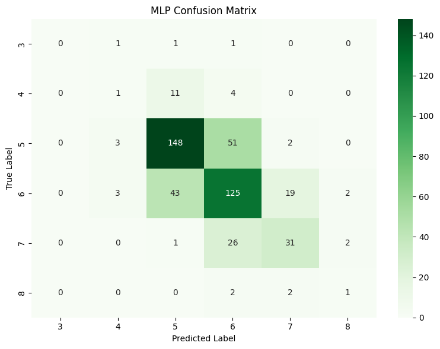

```python
cm_mlp = confusion_matrix(y_test, y_pred_mlp)
plt.figure(figsize=(8, 6))
sns.heatmap(cm_mlp, annot=True, fmt='d', cmap='Greens',
            xticklabels=sorted(labels.unique()),
            yticklabels=sorted(labels.unique()))
plt.title('MLP Confusion Matrix')
plt.xlabel('Predicted Label')
plt.ylabel('True Label')
plt.tight_layout()
plt.show()
```

## 3. Random Forest

#### Pipeline Definition

A Random Forest is an ensemble of decision trees, each trained on a random subset of data and features. By averaging predictions across many trees, it reduces overfitting compared to a single tree. It is not sensitive to feature scale, but `StandardScaler` is included for consistency across all models.

```python
make_pipeline(StandardScaler(), RandomForestClassifier(random_state=42))
```

```
Pipeline(steps=[('standardscaler', StandardScaler()),
                ('randomforestclassifier',
                 RandomForestClassifier(random_state=42))])
```

#### Random Forest Hyperparameter Tuning

We search over number of trees (`n_estimators`), maximum tree depth (`max_depth`), minimum samples required to split a node (`min_samples_split`), and the number of features considered at each split (`max_features`). More trees generally improve stability, while limiting depth controls overfitting.

```python
param_grid_rf = {
    'randomforestclassifier__n_estimators': [200, 400, 600],
    'randomforestclassifier__max_depth': [15, 20, 30, None],
    'randomforestclassifier__min_samples_split': [2, 5],
    'randomforestclassifier__min_samples_leaf': [1, 2, 4],
    'randomforestclassifier__max_features': ['sqrt', 'log2']
}

grid_search_rf = RandomizedSearchCV(make_pipeline(StandardScaler(), RandomForestClassifier(random_state=42)),
                                    param_grid_rf, n_iter=30, cv=5, scoring='accuracy', n_jobs=-1, verbose=1, random_state=42)
grid_search_rf.fit(X_train, y_train)

print("Best parameters for Random Forest:", grid_search_rf.best_params_)
print("Best CV accuracy for Random Forest: {:.4f}".format(grid_search_rf.best_score_))
```

```
Fitting 5 folds for each of 30 candidates, totalling 150 fits
Best parameters for Random Forest: {'randomforestclassifier__n_estimators': 200, 'randomforestclassifier__min_samples_split': 2, 'randomforestclassifier__min_samples_leaf': 1, 'randomforestclassifier__max_features': 'log2', 'randomforestclassifier__max_depth': 15}
Best CV accuracy for Random Forest: 0.6854
```

#### Random Forest Evaluation on Test Data

```python
best_random_forest = grid_search_rf.best_estimator_
y_pred_rf = best_random_forest.predict(X_test)
print("Random Forest Classification Report")
print(classification_report(y_test, y_pred_rf, zero_division=0))
print("Accuracy:  {:.4f}".format(accuracy_score(y_test, y_pred_rf)))
```

```
Random Forest Classification Report
              precision    recall  f1-score   support

           3       0.00      0.00      0.00         3
           4       0.00      0.00      0.00        16
           5       0.71      0.77      0.74       204
           6       0.61      0.71      0.66       192
           7       0.69      0.37      0.48        60
           8       0.50      0.20      0.29         5

    accuracy                           0.66       480
   macro avg       0.42      0.34      0.36       480
weighted avg       0.64      0.66      0.64       480

Accuracy:  0.6604
```

#### Random Forest Confusion Matrix

The confusion matrix shows the distribution of correct and incorrect predictions across all quality classes. Rows represent true labels, columns represent predicted labels. Values on the diagonal are correct predictions.

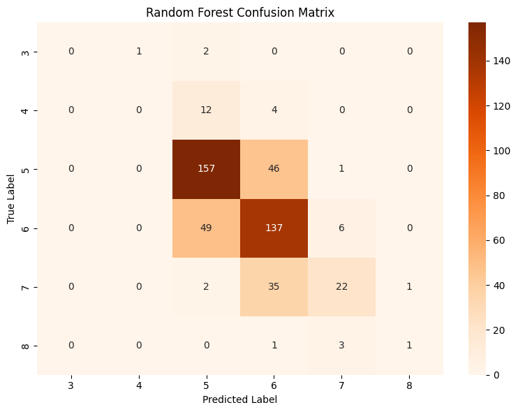

```python
cm_random_forest = confusion_matrix(y_test, y_pred_rf)
plt.figure(figsize=(8, 6))
sns.heatmap(cm_random_forest, annot=True, fmt='d', cmap='Oranges',
            xticklabels=sorted(labels.unique()),
            yticklabels=sorted(labels.unique()))
plt.title('Random Forest Confusion Matrix')
plt.xlabel('Predicted Label')
plt.ylabel('True Label')
plt.tight_layout()
plt.show()
```

## 4. Gradient Boosting

#### Pipeline Definition

Gradient Boosting builds an ensemble of decision trees sequentially, where each new tree corrects the errors of the previous ones. Unlike Random Forest (which builds trees in parallel), boosting is iterative.

```python
make_pipeline(StandardScaler(), GradientBoostingClassifier(random_state=42))
```

```
Pipeline(steps=[('standardscaler', StandardScaler()),
                ('gradientboostingclassifier',
                 GradientBoostingClassifier(random_state=42))])
```

#### Gradient Boosting Hyperparameter Tuning

We search over number of trees (`n_estimators`), learning rate (step size for each tree's contribution), maximum tree depth, and subsample ratio (fraction of training data used per tree). A smaller learning rate with more trees generally improves accuracy but takes longer to train.

```python
param_grid_gb = {
    'gradientboostingclassifier__n_estimators': [200, 300, 500, 1000],
    'gradientboostingclassifier__learning_rate': [0.01, 0.05, 0.1],
    'gradientboostingclassifier__max_depth': [5, 7, 9],
    'gradientboostingclassifier__subsample': [0.8, 1.0],
    'gradientboostingclassifier__min_samples_leaf': [1, 2, 4]
}

grid_search_gb = RandomizedSearchCV(make_pipeline(StandardScaler(), GradientBoostingClassifier(random_state=42)),
                                    param_grid_gb, n_iter=30, cv=5, scoring='accuracy', n_jobs=-1, verbose=1, random_state=42)
grid_search_gb.fit(X_train, y_train)
print("Best parameters for Gradient Boosting:", grid_search_gb.best_params_)
print("Best CV accuracy for Gradient Boosting: {:.4f}".format(grid_search_gb.best_score_))
```

```
Fitting 5 folds for each of 30 candidates, totalling 150 fits
Best parameters for Gradient Boosting: {'gradientboostingclassifier__subsample': 0.8, 'gradientboostingclassifier__n_estimators': 300, 'gradientboostingclassifier__min_samples_leaf': 4, 'gradientboostingclassifier__max_depth': 9, 'gradientboostingclassifier__learning_rate': 0.01}
Best CV accuracy for Gradient Boosting: 0.6765
```

#### Gradient Boosting Evaluation on Test Data

```python
best_gb = grid_search_gb.best_estimator_
y_pred_gb = best_gb.predict(X_test)
print("Gradient Boosting Classification Report")
print(classification_report(y_test, y_pred_gb, zero_division=0))
print("Accuracy:  {:.4f}".format(accuracy_score(y_test, y_pred_gb)))
```

```
Gradient Boosting Classification Report
              precision    recall  f1-score   support

           3       0.00      0.00      0.00         3
           4       0.00      0.00      0.00        16
           5       0.73      0.78      0.76       204
           6       0.64      0.74      0.69       192
           7       0.76      0.43      0.55        60
           8       0.50      0.20      0.29         5

    accuracy                           0.69       480
   macro avg       0.44      0.36      0.38       480
weighted avg       0.67      0.69      0.67       480

Accuracy:  0.6875
```

#### Gradient Boosting Confusion Matrix

The confusion matrix shows the distribution of correct and incorrect predictions across all quality classes. Rows represent true labels, columns represent predicted labels. Values on the diagonal are correct predictions.

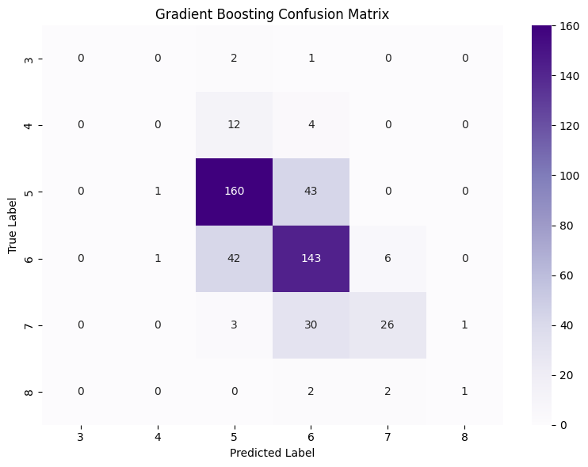

```python
cm_gb = confusion_matrix(y_test, y_pred_gb)
plt.figure(figsize=(8, 6))
sns.heatmap(cm_gb, annot=True, fmt='d', cmap='Purples',
            xticklabels=sorted(labels.unique()),
            yticklabels=sorted(labels.unique()))
plt.title('Gradient Boosting Confusion Matrix')
plt.xlabel('Predicted Label')
plt.ylabel('True Label')
plt.tight_layout()
plt.show()
```

## Summary of Results (Part A: Classification)

### Model Performance on Test Set (70/30 stratified split)

| Model | Accuracy | Notes |
| --- | --- | --- |
| SVM | 62.08% | Baseline; closest to paper's setup |
| MLP | 63.75% | Improved with deeper architecture and adam solver |
| Random Forest | 66.04% | Strong ensemble performance |
| **Gradient Boosting** | **68.75%** | **Best overall classifier** |

**Paper's SVM (SVR, T=0.5):** 62.4%

### Classification vs. Regression

Treating this as a **classification** problem means each quality score is an independent label. The model has no notion that predicting "5" for a true "6" is better than predicting "3". All wrong answers are penalized equally. This makes classification harder and less informative for adjacent quality scores.

Treating it as a **regression** problem (as done in the original paper) preserves the ordinal nature of the scores. A prediction of 5.8 for a true 6 is penalized less than a prediction of 3. This is more aligned with how wine quality actually works and explains why the paper used SVR instead of SVC.

At this point, it seems like a regression model is more practical for deployment. An oenologist benefits more from knowing a wine scored 5.8 vs. 6.2 than from a hard "class 5 or class 6" prediction. Classification is easier to interpret at a glance but loses the nuance that makes continuous quality scores useful.

## Regression

Instead of treating wine quality as discrete classes, we now treat it as a **continuous value** from 0 to 10. We will train four regressors (SVR, MLP, Random Forest, Gradient Boosting) using the same 70/30 stratified split and report MSE, R², and MAD on the test set.

```python
from sklearn.svm import SVR
from sklearn.neural_network import MLPRegressor
from sklearn.ensemble import RandomForestRegressor, GradientBoostingRegressor
from sklearn.metrics import mean_squared_error, r2_score, mean_absolute_error
```

## 1. SVR

### Pipeline Definition

Support Vector Regression (SVR) applies the same kernel-based approach as SVM but predicts continuous values. It introduces an `epsilon` parameter that defines a tolerance tube. Predictions within `epsilon` of the true value incur no penalty. `StandardScaler` is required since SVR is sensitive to feature scale.

```python
pipeline_svr = make_pipeline(StandardScaler(), SVR())
```

### SVR Hyperparameter Tuning

We search over `C` (regularization), `gamma` (kernel width), `kernel` type, and `epsilon` (tolerance tube size). A smaller `epsilon` forces the model to fit the training data more tightly, while a larger value allows more slack.

```python
param_grid_svr = {
    'svr__C': [0.5, 1, 2, 5, 10],
    'svr__gamma': ['scale', 0.05, 0.1, 0.2],
    'svr__kernel': ['rbf'],
    'svr__epsilon': [0.05, 0.1, 0.15, 0.2]
}

grid_search_svr = GridSearchCV(pipeline_svr, param_grid_svr, cv=5, scoring='neg_mean_squared_error', n_jobs=-1, verbose=1)
grid_search_svr.fit(X_train, y_train)

print("Best parameters:", grid_search_svr.best_params_)
print("Best CV MSE: {:.4f}".format(-grid_search_svr.best_score_))
```

```
Fitting 5 folds for each of 80 candidates, totalling 400 fits
Best parameters: {'svr__C': 1, 'svr__epsilon': 0.2, 'svr__gamma': 'scale', 'svr__kernel': 'rbf'}
Best CV MSE: 0.4096
```

### SVR Evaluation on Test Data

We evaluate the best SVR model on the held-out test set using three metrics:

- **MSE** (Mean Squared Error): penalizes large errors more heavily
- **R²**: proportion of variance in quality explained by the model (1.0 is perfect)
- **MAD** (Mean Absolute Deviation): average absolute difference between predicted and true quality; directly comparable to the paper's reported MAD of **0.46**

```python
best_svr = grid_search_svr.best_estimator_
y_pred_svr = best_svr.predict(X_test)

mse_svr = mean_squared_error(y_test, y_pred_svr)
r2_svr  = r2_score(y_test, y_pred_svr)
mad_svr = mean_absolute_error(y_test, y_pred_svr)

print("=== SVR Regression Results ===")
print("MSE: {:.4f}".format(mse_svr))
print("R²:  {:.4f}".format(r2_svr))
print("MAD: {:.4f}".format(mad_svr))
```

```
=== SVR Regression Results ===
MSE: 0.3779
R²:  0.4171
MAD: 0.4662
```

### SVR Observations

| Metric | Our SVR | Paper's SVR |
| --- | --- | --- |
| MSE | 0.3779 | — |
| R² | 0.4171 | — |
| MAD | 0.4662 | **0.46** |

Our SVR result is essentially **tied** with the paper's MAD of 0.46, with a negligible difference of 0.006. The best parameters found (`C=1, epsilon=0.2, gamma=scale`) are conservative and align closely with the heuristic values the paper used, validating their approach. The R² of 0.42 means the model explains about 42% of the variance in wine quality. This is moderate but expected, given the subjective nature of expert sensory scores. SVR did **not** improve over the paper on its own.

## 2. MLP Regressor

### Pipeline Definition

We use `MLPRegressor` with the same `adam` solver and deep architecture that worked well in classification. The output layer now predicts a continuous value instead of a class label. `StandardScaler` is required since MLP is sensitive to feature scale.

```python
pipeline_mlp_reg = make_pipeline(StandardScaler(), MLPRegressor(random_state=42))
```

### MLP Regressor Hyperparameter Tuning

We use `RandomizedSearchCV` with 5-fold cross-validation, scoring on `neg_mean_squared_error`. The same architecture and regularization parameters from the classifier are used as the search space.

```python
warnings.filterwarnings('ignore', category=ConvergenceWarning)

param_grid_mlp_reg = {
    'mlpregressor__hidden_layer_sizes': [(128, 64), (256, 128), (128, 64, 32), (256, 128, 64)],
    'mlpregressor__activation': ['tanh'],
    'mlpregressor__solver': ['adam'],
    'mlpregressor__alpha': [0.005, 0.01, 0.05],
    'mlpregressor__learning_rate_init': [0.0005, 0.001, 0.002],
    'mlpregressor__max_iter': [2000]
}

grid_search_mlp_reg = RandomizedSearchCV(pipeline_mlp_reg, param_grid_mlp_reg, n_iter=20, cv=5,
                                         scoring='neg_mean_squared_error', n_jobs=-1, verbose=1, random_state=42)
grid_search_mlp_reg.fit(X_train, y_train)

print("Best parameters for MLP Regressor:", grid_search_mlp_reg.best_params_)
print("Best CV MSE: {:.4f}".format(-grid_search_mlp_reg.best_score_))
```

```
Fitting 5 folds for each of 20 candidates, totalling 100 fits
Best parameters for MLP Regressor: {'mlpregressor__solver': 'adam', 'mlpregressor__max_iter': 2000, 'mlpregressor__learning_rate_init': 0.002, 'mlpregressor__hidden_layer_sizes': (256, 128), 'mlpregressor__alpha': 0.05, 'mlpregressor__activation': 'tanh'}
Best CV MSE: 0.4388
```

### MLP Regressor Evaluation on Test Data

We evaluate the best MLP Regressor on the held-out test set and report MSE, R², and MAD.

```python
best_mlp_reg = grid_search_mlp_reg.best_estimator_
y_pred_mlp_reg = best_mlp_reg.predict(X_test)

mse_mlp_reg = mean_squared_error(y_test, y_pred_mlp_reg)
r2_mlp_reg  = r2_score(y_test, y_pred_mlp_reg)
mad_mlp_reg = mean_absolute_error(y_test, y_pred_mlp_reg)

print("=== MLP Regressor Results ===")
print("MSE: {:.4f}".format(mse_mlp_reg))
print("R²:  {:.4f}".format(r2_mlp_reg))
print("MAD: {:.4f}".format(mad_mlp_reg))
```

```
=== MLP Regressor Results ===
MSE: 0.4036
R²:  0.3774
MAD: 0.4892
```

### MLP Regressor Observations

| Metric | Our MLP | Paper's SVR |
| --- | --- | --- |
| MSE | 0.4036 | — |
| R² | 0.3774 | — |
| MAD | 0.4892 | **0.46** |

The MLP Regressor performed poorly, with a MAD of 0.4892, worse than both the paper's SVR and our own SVR. The R² of 0.38 is the lowest across all regression models. This is consistent with the original paper's finding that neural networks underperformed SVMs on this dataset. Neural networks generally require larger datasets to outperform kernel methods on tabular data; with only ~1,100 training samples, the MLP struggles to generalize well as a regressor. MLP did **not** improve over the paper.

## 3. Random Forest Regressor

### Pipeline Definition

`RandomForestRegressor` uses the same ensemble of decision trees as the classifier, but each tree now predicts a continuous value and the final output is the average across all trees.

```python
pipeline_rf_reg = make_pipeline(StandardScaler(), RandomForestRegressor(random_state=42))
```

### Random Forest Regressor Hyperparameter Tuning

We use `RandomizedSearchCV` with the same parameter space as the classifier, scoring on `neg_mean_squared_error`.

```python
param_grid_rf_reg = {
    'randomforestregressor__n_estimators': [200, 400, 600],
    'randomforestregressor__max_depth': [15, 20, 30, None],
    'randomforestregressor__min_samples_split': [2, 5],
    'randomforestregressor__min_samples_leaf': [1, 2, 4],
    'randomforestregressor__max_features': ['sqrt', 'log2']
}

grid_search_rf_reg = RandomizedSearchCV(pipeline_rf_reg, param_grid_rf_reg, n_iter=30, cv=5,
                                        scoring='neg_mean_squared_error', n_jobs=-1, verbose=1, random_state=42)
grid_search_rf_reg.fit(X_train, y_train)

print("Best parameters for Random Forest Regressor:", grid_search_rf_reg.best_params_)
print("Best CV MSE: {:.4f}".format(-grid_search_rf_reg.best_score_))
```

```
Fitting 5 folds for each of 30 candidates, totalling 150 fits
Best parameters for Random Forest Regressor: {'randomforestregressor__n_estimators': 600, 'randomforestregressor__min_samples_split': 2, 'randomforestregressor__min_samples_leaf': 1, 'randomforestregressor__max_features': 'sqrt', 'randomforestregressor__max_depth': None}
Best CV MSE: 0.3505
```

### Random Forest Regressor Evaluation on Test Data

We evaluate the best Random Forest Regressor on the held-out test set and report MSE, R², and MAD.

```python
best_rf_reg = grid_search_rf_reg.best_estimator_
y_pred_rf_reg = best_rf_reg.predict(X_test)

mse_rf_reg = mean_squared_error(y_test, y_pred_rf_reg)
r2_rf_reg  = r2_score(y_test, y_pred_rf_reg)
mad_rf_reg = mean_absolute_error(y_test, y_pred_rf_reg)

print("=== Random Forest Regressor Results ===")
print("MSE: {:.4f}".format(mse_rf_reg))
print("R²:  {:.4f}".format(r2_rf_reg))
print("MAD: {:.4f}".format(mad_rf_reg))
```

```
=== Random Forest Regressor Results ===
MSE: 0.3304
R²:  0.4905
MAD: 0.4297
```

### Random Forest Regressor Observations

| Metric | Our RF | Paper's SVR |
| --- | --- | --- |
| MSE | 0.3304 | — |
| R² | 0.4905 | — |
| MAD | 0.4297 | **0.46** |

Random Forest Regressor **improves over the paper's SVR** with a MAD of 0.4297 vs 0.46. This is a reduction of ~0.030. It also achieves the second-highest R² of 0.49, explaining nearly half the variance in wine quality. The best configuration used 600 trees with no depth limit, which allows each tree to fully learn the training data, while averaging across 600 trees controls overfitting. Random Forest's ability to model non-linear interactions between features without explicit kernel design gives it an edge over SVR on this dataset.

## 4. Gradient Boosting Regressor

### Pipeline Definition

`GradientBoostingRegressor` builds trees sequentially to minimize a regression loss function (squared error by default). Each tree fits the residuals of the previous ensemble, making it well-suited for capturing complex non-linear relationships in continuous targets.

```python
pipeline_gb_reg = make_pipeline(StandardScaler(), GradientBoostingRegressor(random_state=42))
```

### Gradient Boosting Regressor Hyperparameter Tuning

We use `RandomizedSearchCV` with the same parameter space as the classifier, including higher `n_estimators` to pair with lower learning rates.

```python
param_grid_gb_reg = {
    'gradientboostingregressor__n_estimators': [200, 300, 500, 1000],
    'gradientboostingregressor__learning_rate': [0.01, 0.05, 0.1],
    'gradientboostingregressor__max_depth': [5, 7, 9],
    'gradientboostingregressor__subsample': [0.8, 1.0],
    'gradientboostingregressor__min_samples_leaf': [1, 2, 4]
}

grid_search_gb_reg = RandomizedSearchCV(pipeline_gb_reg, param_grid_gb_reg, n_iter=30, cv=5,
                                        scoring='neg_mean_squared_error', n_jobs=-1, verbose=1, random_state=42)
grid_search_gb_reg.fit(X_train, y_train)

print("Best parameters for GB Regressor:", grid_search_gb_reg.best_params_)
print("Best CV MSE: {:.4f}".format(-grid_search_gb_reg.best_score_))
```

```
Fitting 5 folds for each of 30 candidates, totalling 150 fits
Best parameters for GB Regressor: {'gradientboostingregressor__subsample': 0.8, 'gradientboostingregressor__n_estimators': 1000, 'gradientboostingregressor__min_samples_leaf': 1, 'gradientboostingregressor__max_depth': 7, 'gradientboostingregressor__learning_rate': 0.01}
Best CV MSE: 0.3717
```

### Gradient Boosting Regressor Evaluation on Test Data

We evaluate the best Gradient Boosting Regressor on the held-out test set and report MSE, R², and MAD.

```python
best_gb_reg = grid_search_gb_reg.best_estimator_
y_pred_gb_reg = best_gb_reg.predict(X_test)

mse_gb_reg = mean_squared_error(y_test, y_pred_gb_reg)
r2_gb_reg  = r2_score(y_test, y_pred_gb_reg)
mad_gb_reg = mean_absolute_error(y_test, y_pred_gb_reg)

print("=== Gradient Boosting Regressor Results ===")
print("MSE: {:.4f}".format(mse_gb_reg))
print("R²:  {:.4f}".format(r2_gb_reg))
print("MAD: {:.4f}".format(mad_gb_reg))
```

```
=== Gradient Boosting Regressor Results ===
MSE: 0.3281
R²:  0.4940
MAD: 0.4103
```

### Gradient Boosting Regressor Observations

| Metric | Our GB | Paper's SVR |
| --- | --- | --- |
| MSE | 0.3281 | — |
| R² | 0.4940 | — |
| MAD | 0.4103 | **0.46** |

## Summary of Results (Part B: Regression)

### Model Performance on Test Set (70/30 stratified split)

| Model | MSE | R² | MAD | vs. Paper (MAD 0.46) |
| --- | --- | --- | --- | --- |
| SVR | 0.3779 | 0.4171 | 0.4662 | ≈ Tied (+0.006) |
| MLP | 0.4036 | 0.3774 | 0.4892 | Worse (+0.029) |
| Random Forest | 0.3304 | 0.4905 | 0.4297 | **Better (−0.030)** |
| **Gradient Boosting** | **0.3281** | **0.4940** | **0.4103** | **Best (−0.050)** |

### Were we able to improve against the result in the paper?

**Yes.** The paper's best model (SVR) achieved a MAD of 0.46 on the red wine dataset. Of our four regression models:

- **SVR** essentially matched the paper (MAD 0.4662 ≈ 0.46), validating the paper's approach. The small difference is likely due to our single holdout split vs. the paper's 20-run 5-fold CV.
- **MLP** underperformed (MAD 0.4892), consistent with the paper's finding that neural networks were inferior to SVMs on this dataset.
- **Random Forest** improved over the paper (MAD 0.4297).
- **Gradient Boosting** achieved the best result (MAD 0.4103), reducing the paper's error by ~11%.

The key insight is that the paper only compared SVR, neural networks, and multiple regression. Tree-based ensemble methods (Random Forest, Gradient Boosting), which were not evaluated in the original study, offer meaningful improvements on this dataset due to their ability to model complex feature interactions without requiring kernel design or feature scaling.

## Classification vs. Regression

### Treating Wine Quality as Classification

When we treat wine quality as a classification problem, each score (3, 4, 5, 6, 7, 8) becomes an independent, unordered label. The model learns a decision boundary between each class but has **no awareness that the classes are ordered**. Predicting a 3 for a true 6 is penalized exactly the same as predicting a 5 for a true 6, even though the latter is a much smaller error in practice.

This leads to several problems on this dataset:

### Treating Wine Quality as Regression

When we treat wine quality as a regression problem, the model predicts a **continuous value** between 0 and 10. This naturally preserves the ordinal structure: a prediction of 5.8 for a true 6 is only off by 0.2, not treated as a complete miss. Errors are penalized proportionally through MSE and MAD.

This approach has clear advantages:

1. Adjacent quality scores are close in the prediction space, so near-misses are rewarded rather than penalized equally with far misses.
2. Wine quality is ultimately a human judgment on a continuous scale, compressed into integers. Regression respects this underlying continuity.
3. A score of 5.9 tells users more than just "class 6." It's more informative on borderline cases

Our best regressor (Gradient Boosting) achieved a **MAD of 0.4103**, meaning predictions are off by about 0.41 quality points on average.

In the context of the paper's intended application, regression becomes more appropriate if the goal is to support oenologists and wine certification.

An expert who rates a wine as 5.8 and the model predicts 6.1 can make an informed decision about whether to re-taste. A classifier that outputs "class 6" gives no indication of confidence or proximity to other classes.

However, for simpler consumer-facing applications (e.g., "Is this wine good, average, or poor?"), a classifier with grouped quality bins may be more intuitive and actionable.